# Report 2

Jason Ola

2021-03-03

## Import libraries

```r
library(tidyverse)
library(tidygraph)
library(readxl)
library(ggraph)
```

## Exercise

### Part 1

Let’s first load our edges and nodes data with readxl

```r
edges <- read_excel("data/data.xlsx",
    sheet = "edges")
nodes <- read_excel("data/data.xlsx",
    sheet = "nodes")
```

Now we combine that data into a graph format

```r
graph <- tbl_graph(
  nodes = nodes,
  edges = edges
)
```

Let’s plot the graph architecture

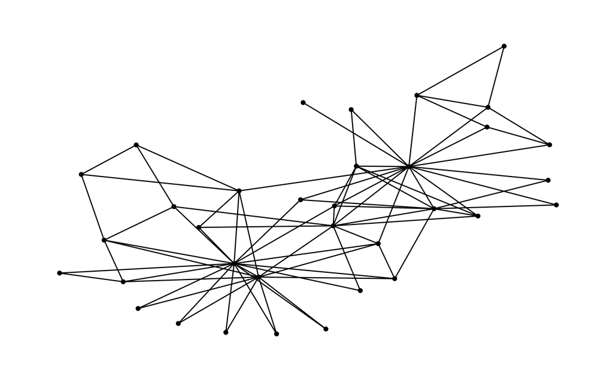

```r
graph %>%
  ggraph(layout = "igraph", algorithm = "kk")+
  geom_edge_fan()+
  geom_node_point()+
  theme_graph()
```

### Part 2

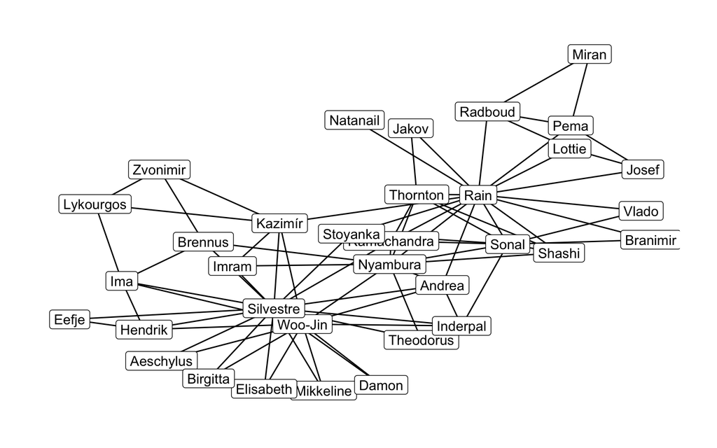

```r
graph %N>%
  mutate(first_name = str_extract(name, "[^ ]+") %>% str_trim()) %>%
  ggraph(layout = "kk")+
  geom_edge_fan()+
  geom_node_label(aes(label = first_name))+
  theme_graph()
```

### Part 3

Let’s first see who has the most edges, first we count the top four id with number of edges with a pivot longer

```r
top4 <- graph %E>%
  as_tibble() %>%
  pivot_longer(c(from,to),values_to = "id") %>%
  count(id) %>%
  slice_max(n,n = 4, with_ties = TRUE) %>%
  pull(id)
```

Then we create a column with highlight to flag our top4 ids

```r
graph_hl <- graph %E>%
  mutate(highlight = if_else(from %in% top4 | to %in% top4, 1, 0))
graph_hl <- graph_hl %N>%
  mutate(highlight = if_else(id %in% top4, 1, 0))
```

Finally we plot the results

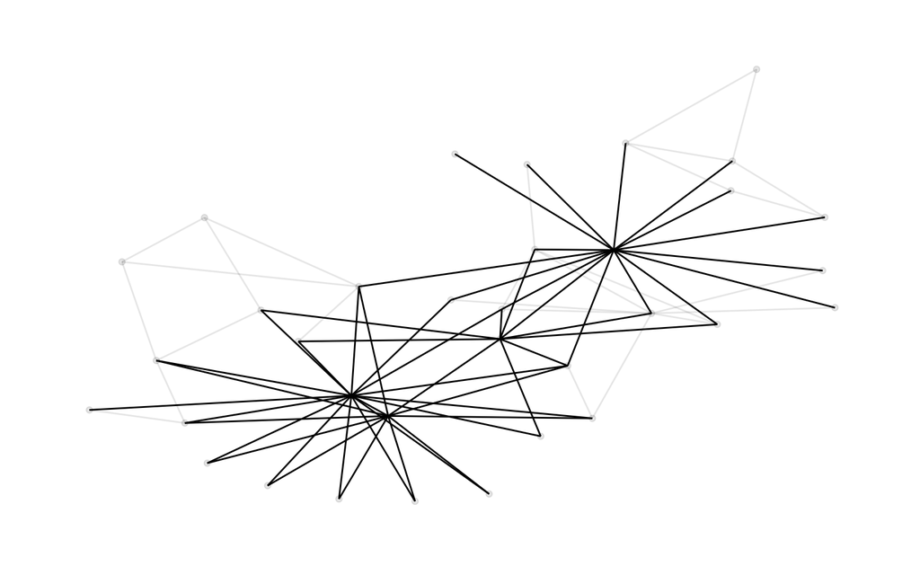

```r
graph_hl %>%
  ggraph(layout = "igraph", algorithm = "kk") +
  geom_edge_fan(aes(alpha = highlight),
                show.legend = FALSE)+
  geom_node_point(alpha = 0.1)+
  theme_graph()
```

```r
top4names <- graph_hl %N>%
  filter(highlight == 1) %>%
  pull(name) %>%
  glue::glue_collapse(", ", last = " and ")
```

```r
top4counts <- graph %E>%
  as_tibble() %>%
  pivot_longer(c(from,to),values_to = "id") %>%
  count(id) %>%
  slice_max(n,n = 4) %>%
  arrange(id) %>%
  pull(n) %>%
  glue::glue_collapse(", ", last = " and ")
```

The 4 names with the most connections are : Rain Lemmi, Nyambura Fischer, Woo-Jin Tosetti and Silvestre Molina, with respectively 16, 10, 12 and 17 connections

### Part 4

Let’s now add our names and other point shapes

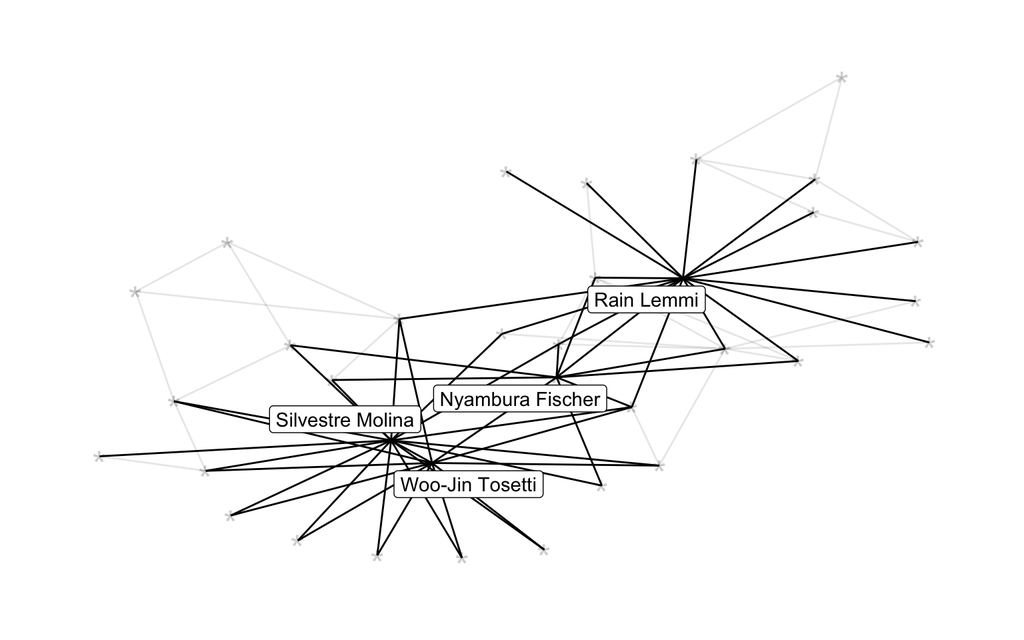

```r
graph_hl %>%
  ggraph(layout = "igraph", algorithm = "kk") +
  geom_edge_fan(aes(alpha = highlight),
                show.legend = FALSE)+
  geom_node_point(alpha = 0.2,
                  shape = "*",
                  size = 7)+
  geom_node_label(aes(label = if_else(highlight == 1, name, NULL)),
                  repel = TRUE)+
  theme_graph()
```

### Part 5

Now let’s color the edges and nodes by these 4 central figures, we need to mutate both tables to have color column with desired color

```r
graph_hl <- graph_hl %>%
  mutate(color = case_when(id == 34 ~ "darkblue",
                           id == 1 ~ "darkred",
                           id == 33 ~ "darkgreen",
                           id == 3 ~ "purple",
                           TRUE ~ "gray"))
graph_hl <- graph_hl %E>%
  mutate(color = case_when(from == 34 | to == 34 ~ "darkblue",
                           from == 1 | to == 1 ~ "darkred",
                           from == 33 | to == 33 ~ "darkgreen",
                           from == 3 | to == 3 ~ "purple",
                           TRUE ~ "gray"))
```

We color the nodes and edges in the plot with scale color identity

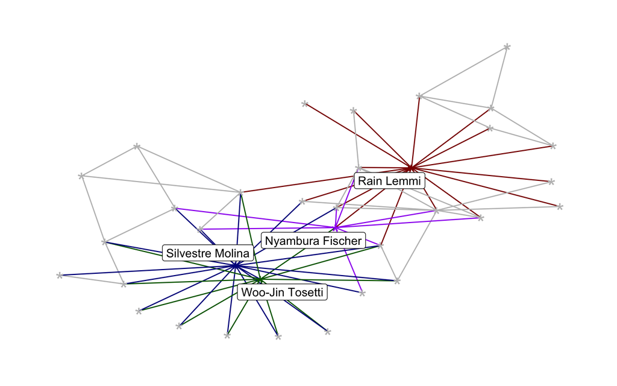

```r
graph_hl %>%
  ggraph(layout = "igraph", algorithm = "kk") +
  geom_edge_fan(aes(color = color),
                show.legend = FALSE)+
  geom_node_point(shape = "*",
                  size = 7,
                  mapping = aes(color = color))+
  geom_node_label(aes(label = if_else(highlight == 1, name, NULL)),
                  repel = TRUE)+
  scale_edge_color_identity (breaks = graph_hl$color)+
  scale_color_identity (breaks = graph_hl$color)+
  theme_graph()
```

### Part 6

Now we can polish our graph

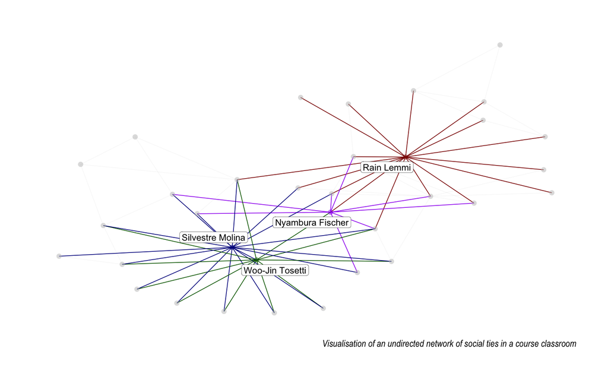

```r
graph_hl %>%
  ggraph(layout = "igraph", algorithm = "kk") +
  geom_edge_fan(aes(color = color,
                    alpha = highlight),
                width = 0.3,
                show.legend = FALSE)+
  geom_node_point(shape = 16,
                  size = 2,
                  alpha = 0.5,
                  mapping = aes(color = color))+
  geom_node_label(aes(label = if_else(highlight == 1, name, NULL)),
                  repel = TRUE,
                  size = 3,
                  label.padding = 0.15,
                  label.size = 0.1)+
  scale_edge_color_identity (breaks = graph_hl$color)+
  scale_color_identity (breaks = graph_hl$color)+
  theme_graph()+
  labs(caption = "Visualisation of an undirected network of social ties in a course classroom")
```